# Introduction to R for undergraduates in economics

### The merge() function

An important function for working with data.frames is the merge() function. This allows us to combine multiple tables by merging a common variable name. Let's merge the two tables 'students' and 'marks' to find out the mark earned by each student.

```r
student.grades <- merge(students, marks, by = 'MODULE')
student.grades
```

A data.frame: 4 × 4

| MODULE <chr> | STUDENT <chr> | ESSAY_MARK <dbl> | EXAM_MARK <dbl> |
| --- | --- | --- | --- |
| Law and Economics | R. Coase | 70 | 80 |
| Macroeconomics | J.M. Keynes | 75 | 67 |
| Monetary Economics | J. Robinson | 65 | 60 |
| Welfare Economics | A.C. Pigou | 59 | 70 |

by = 'MODULE' means that we merge based on the common variable 'MODULE' in the two tables. If we know what the grade was in each module, and which student took each module, we also know which grade each student got. Merge is a very valueble tool for working with multiple datasets. As economists, we often need to combine data from multiple sources, and in these cases we frequently combine data based on common identifying variables.

```r
student.grades$FINAL_MARK

for (i in 1:nrow(student.grades)) {

    student.grades$FINAL_MARK[i] <- mean(student.grades$ESSAY_MARK[i], student.grades$EXAM_MARK[i])

    if (student.grades$FINAL_MARK[i] >= 70) {

        print(paste(student.grades$STUDENT[i], ' earned a 1st!'))
    }
}

student.grades
```

```
[1] "R. Coase  earned a 1st!"
[1] "J.M. Keynes  earned a 1st!"
```

A data.frame: 4 × 5

| MODULE <chr> | STUDENT <chr> | ESSAY_MARK <dbl> | EXAM_MARK <dbl> | FINAL_MARK <dbl> |
| --- | --- | --- | --- | --- |
| Law and Economics | R. Coase | 70 | 80 | 70 |
| Macroeconomics | J.M. Keynes | 75 | 67 | 75 |
| Monetary Economics | J. Robinson | 65 | 60 | 65 |
| Welfare Economics | A.C. Pigou | 59 | 70 | 59 |

## Plotting

If we want to visualize our data, R offers functionality for that too. To make pretty plots, we want to install and load the package 'ggplot2' which is used to produce publication-quality graphs and figures.

```r
library(ggplot2)
```

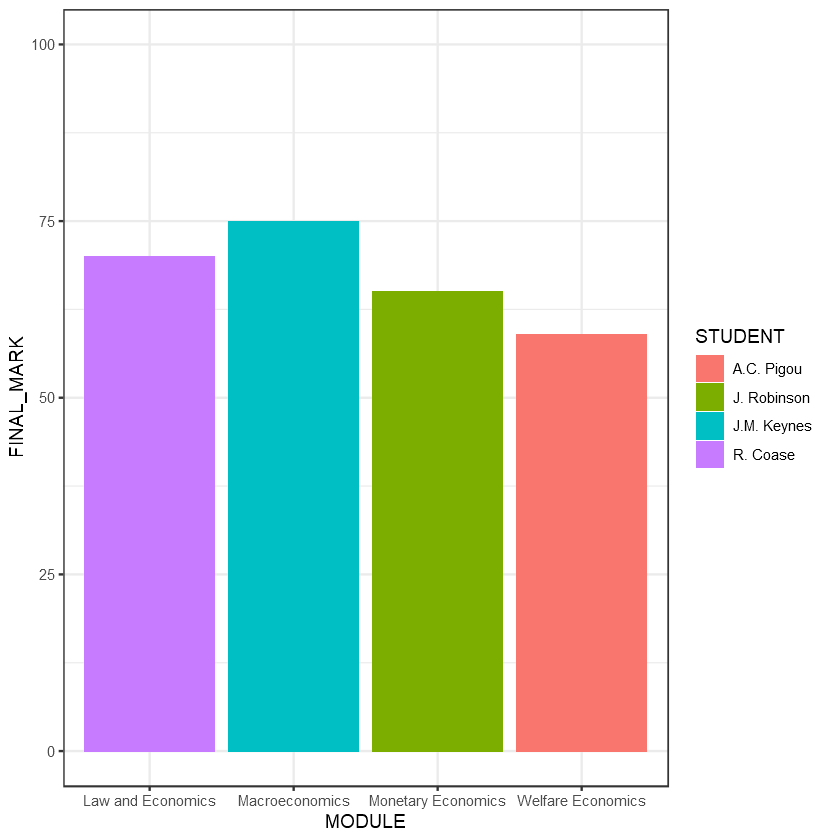

```r
ggplot(data = student.grades, aes(y = FINAL_MARK, x = MODULE, fill = STUDENT)) +
geom_bar(stat='identity') +
ylim(0,100) +
theme_bw()
```

## Further reading

This document was meant to provide the basics to equip you to do simple exercises like the Economics of Sustainability seminar questions in R. However there is much more to learn. Below I list some good resources:

#### 'Introduction to Statistical Learning with Applications in R' by James, Witten, Hastie and Tibshirani. 2013

A highly recommended textbook introducing statistical analysis and machine learning with R. Also comes in a more advanced version 'Elements in Statistical Learning'.

#### https://cran.r-project.org/doc/manuals/r-release/R-intro.pdf and https://cran.r-project.org/doc/contrib/Paradis-rdebuts_en.pdf

A free manual to R from the core R development team. A much more in-depth version of this document.

#### http://www.sthda.com/english/wiki/be-awesome-in-ggplot2-a-practical-guide-to-be-highly-effective-r-software-and-data-visualization

A practical guide to ggplot - learn to make highly AESTHETIC figures and graphs!